# Lab 04 - Project kick-off and data viz exercises

```
##
##  ________________________________________________________
## / This week you will start exploring the project details \
## \ to start working as a group                            /
##  --------------------------------------------------------
##       \
##        \
##
##         ^__^
##         (oo)\ ________
##         (__)\         )\ /\
##              ||------w|
##              ||      ||
```

You, as part of a **team**, will be responsible for the completion of an open ended final project for this course, the goal of which is to tackle an “interesting” real life problem using the tools and techniques covered in this class.

# REQUIRED: Project details

In this week’s workshop you will begin on your group projects. This will be the first exploration stage for the project start. It is crucial to finalize the your groups during this week’s workshop. You will find all the information you will need about the group projects is available in

[Project instruction](https://uoe-ids.netlify.app/assessments/project/)

## GitHub repository

One member of your team should be responsible for managing the repository of your group project. This team member should clone the project template repository from the course GitHub account and add each of the team members as collaborators. Instructions on how to clone a repository, add collaborators and to create a new version control R project can be found in the lab worksheets.

The project template repository can be found [HERE](https://github.com/uoeIDS/project_template)

## Explore your data set

```
##
##  _________________________________________________________
## / As a starting point, you can look at your data to apply \
## \ the tools that we learned so far.                       /
##  ---------------------------------------------------------
##   \
##    \
##
##      .-.
##     (o o)
##     | O \
##      \   \
##       `~~~' [nosig]
```

## OPTIONAL: Some initial data viz exercises

Below are some initial data viz exercises as an additional material for this week. That is why it says **Optional**, there will be usual lab material in the next week’s workshop in week 6, as before. The focus will be data visualization again, and these optional examples are wroth exploring for extra preparation.

If you can not look at these exercises here, it is not a problem but feel free to explore and solve in your spare time.

If you are doing the data viz in R with ggplot2 for the first time, and could not attend the lecture this week, please see weekly slides and also look at the one of the suggested reading material in week 5, as supplementary material:

[R4DS: Chp 3 - Data visualisation](https://r4ds.had.co.nz/data-visualisation.html)

### Data viz with starwars

Let us start with some basics of data viz on the starwars data set.

```r
library(tidyverse)
starwars_df <- starwars
```

To decide, how to create any data viz, this supplementary material can be very useful to explore different types with explanations, and R code examples. I will attach this material for our weekly readings as well;

[From Data to Viz](https://www.data-to-viz.com/)

```
##
##  _______________________________________________________
## / Whenever you do not know where to start for the below \
## | exercises, this can be useful additional interactive  |
## \ material to check!                                    /
##  -------------------------------------------------------
##              \
##               \
##
##                 \`*-.
##                  )  _`-.
##                 .  : `. .
##                 : _   '  \
##                 ; *` _.   `*-._
##                 `-.-'          `-.
##                   ;       `       `.
##                   :.       .       \
##                   .\  .   :   .-'   .
##                   '  `+.;  ;  '      :
##                   :  '  |    ;       ;-.
##                   ; '   : :`-:     _.`* ;
##                .*' /  .*' ; .*`- +'  `*'
##      [bug]     `*-*   `*-*  `*-*'
```

Besides, in your group, discuss possible data viz possibilities together and if you would like to do brainstorming with GenAI, please use the IDS allowed suggested way that I shared last week via ELM + IDS-sidekick prompt. IF you need a recall how to do this, [see the guidance from here](https://uoeids.github.io/labs/lab-GenAI/IDS-GenAI.html).

## Exercise 1.

Glimpse at the starwars data frame.

```r
# your code here
```

## Exercise 2.

Let us star with some small changes.

Modify the following plot to change the color of all points to `"pink"`. Initial code given as;

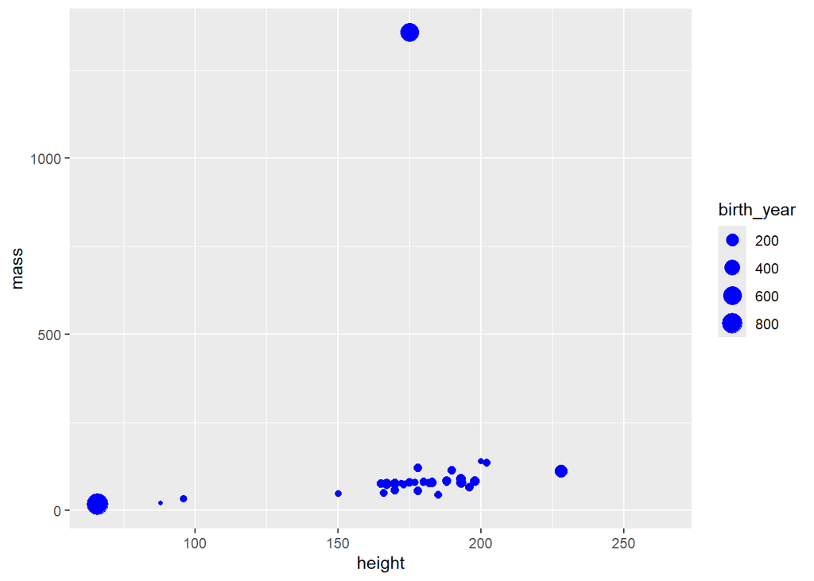

```r
ggplot(starwars_df,
       aes(x = height, y = mass, color = gender, size = birth_year)) +
  geom_point(color = "blue")
```

## Exercise 3

Now for the given visualization, Add labels for title, x and y axes, and size of points. Uncomment what you added before running the code, to see its effect. How about creating the visualization without the labs() layer, what is the difference there ?

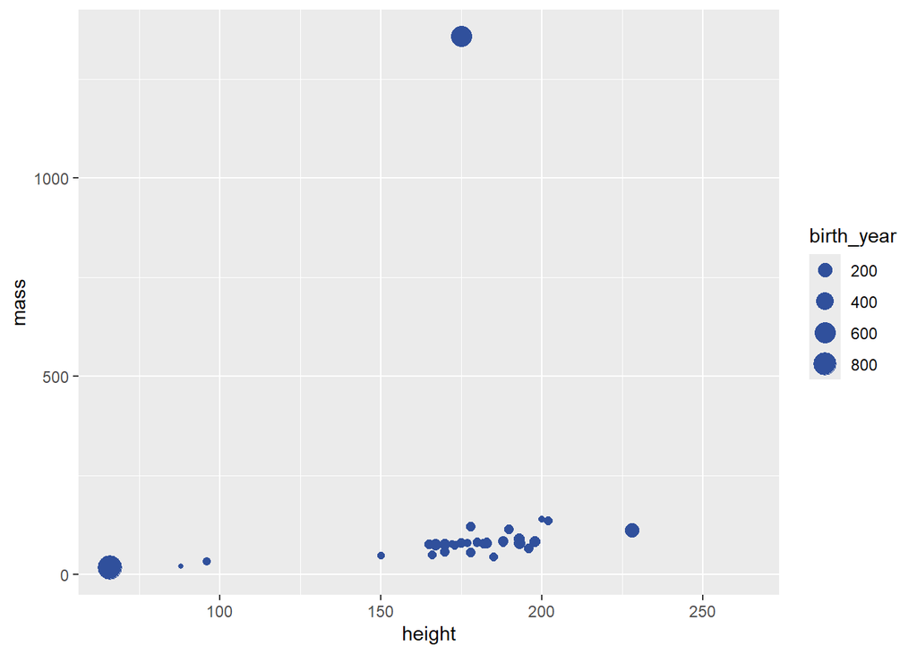

```r
ggplot(starwars,
       aes(x = height, y = mass, color = gender, size = birth_year)) +
  geom_point(color = "#30509C") +
  labs(
    #title = "___",
    #x = "___",
    #y = "___",
    #___
    )
```

## Êxercise 4

By looking at the starwars data, now it is time to pick a single numerical variable and make a histogram of it via ggplot2.

After creating the histogram via `geom_histogram()`, what if you make a change on the binwidth for it. (Hint:check the help page for the related examples in R via `help(geom_histogram)`)

```r
# your code here
```

## Exercise 5

Now, pick a numerical variable and a categorical variable from starwars data set and make a visualization (you can pick the type! via suitable geom_xx() style function) for the relationship between these two variables. Along with your code and output, provide an interpretation of the visualization.

```r
# your code here
```

## Exercise 6

What about picking a single categorical variable from the data set and make a bar plot of its distribution. (Hint: now you can consider the `geom_bar()` with a suitably selected variable). What happen if you apply this logic to a numerical variable?

```r
# your code here
```

## Exercise 7

Now time to pick two categorical variables and make a visualization to visualize the relationship between the two variables. Which type of visualization can be useful do you think and why ? Check the previously suggested [From Data to Viz](https://www.data-to-viz.com/) if you do not where to start.

Along with your code and output, provide an interpretation of the visualization.

```r
# your code here
```

## Exercise 8

How about picking two numerical variables and two categorical variables and make a visualization that incorporates all of them. Are you able to create multiple plots using additional aesthetics ?

You can consider height, mass, gender and species if you like to start with After creating your visualization, provide a brief interpretation for that outcome.

```r
# your code here
```

## If you come to that point

Now it is worth exploring your project data set with your new data viz skills as well. As you recall, understanding your project data includes some EDA that we discussed and creating various data visualizations from your project data will be useful for your research question formulation and also good set of practices.

We will see more examples next week to sharpen your data viz skills. Please share your follow up questions via EdStem, outside of the main contact hours, if you need help for your coding journey.